# Expert Evaluation

Author

Riccardo Volpato

# Survey

This is what experts read during their evaluation of questions.

> The purpose of our research is to develop and validate a scale to measures how much people trust generative AIs (like ChatGPT or Claude) for psychological support, such as discussing feelings, sharing worries, or seeking advice about relationships.

> As part of this process, we are conducting an expert content evaluation to assess whether the items in our scale are clear, relevant, and appropriate. Over the next few sections, you will see items from our scale grouped by the theoretical factor that we assigned to them.

> Across factors, for each item please indicate whether to:
> - **Keep** – retain the item as written
> - **Drop** – remove the item from the scale
> - **Reword** – revise the item wording (you will optionally be able to provide a suggested rewording

> Note that participants in our survey will not see the survey as you will. They will not see any of the factor groupings and will be asked to rate agreement with each item on a 7-point Likert scale (rather than suggesting whether to keep/drop/reword the item).

> **Question:** Which areas best describe your expertise? Please select all that apply
> - Human–AI interaction
> - Digital mental health
> - Psychotherapy or counselling psychology
> - Affective computing
> - Psychometrics / psychological scale development
> - Philosophy / ethics of AI

# Dimensions

These are the candidate dimensions that we showed to expert and their explanations:

1. **Psychological Competence:** Belief that the AI can provide accurate psychological information and help make sense of personal challenges (coded as `COMP`)
2. **Personalisation:** Belief that the AI can recognise individual needs, retain relevant information, and offer support that is tailored to one’s specific situation (coded as `PERS`)
3. **Emotional Intelligence:** Belief that the AI can accurately reflect emotions, make one feel heard, and help shift toward more positive emotional states (coded as `EMOT` and later renamed as *Artificial Emapthy* for reporting)
4. **Psychological Safety:** A sense that the AI provides a private, respectful, unbiased space in which to openly share private thoughts and feelings (coded as `SAFE`)
5. **Risk Perception:** Concern that the AI is ill-equipped to handle serious mental health needs and may provide inaccurate or harmful information (coded as `RISK`)
6. **Corporate Distrust:** Concern that the organisation behind the AI prioritises its own interests over users’ wellbeing, privacy, and values (coded as `CORP`)
7. **Critical Engagement:** The degree to which one maintains personal agency over AI use by questioning its responses, guiding interactions, and trusting one’s own judgment over the AI’s (coded as `CRIT`)
8. **“Artificial Humanness”:** Recognition that the AI communicates in human-like ways while differing from humans in its lack of embodied emotion and shared experience, and an adjustment of one’s expectations and reliance accordingly (coded as `HUMN` and later renamed as *Sentience Attribution* for reporting)

For question wordings see, expert-evaluation_qs.csv

# Data Processing

```r
library(tidyverse)
library(gtools)
library(psych)
library(irr)
library(knitr)
```

```r
options(readr.show_col_types = FALSE)
file_path <- "data/shared/TPSai+-+Experts.csv"
raw_data <- read_csv(file_path, n_max = 2)
colnames <- names(raw_data)
question_labels <- setNames(sub(" - .*", "", as.character(raw_data[1, ])), colnames)
raw_data <- read_csv(file_path, col_names = colnames, skip = 2)
```

```r
factors_map <- read_csv('surveys/expert-evaluation_qs.csv')
cols_tpsai <- factors_map$IID
choices <- c("Keep" = 1, "Drop" = 2, "Reword" = 3)
```

```r
# check that survey and factors correspond (should be empty dataframe)
data.frame(
  question_label = unlist(question_labels[cols_tpsai]),
  factor_item = factors_map$Item,
  match = unlist(question_labels[cols_tpsai]) == factors_map$Item
) %>% filter(!match)  %>% nrow() == 0
```

```
[1] TRUE
```

```r
analysis_data <- raw_data

experts_data <- analysis_data %>%
  select(all_of(cols_tpsai))  %>%
  mutate(across(all_of(cols_tpsai), ~ choices[.x]))
```

# Expertise

Examining the inter-disciplinary nature of expertise by showing which expert had which expertise.

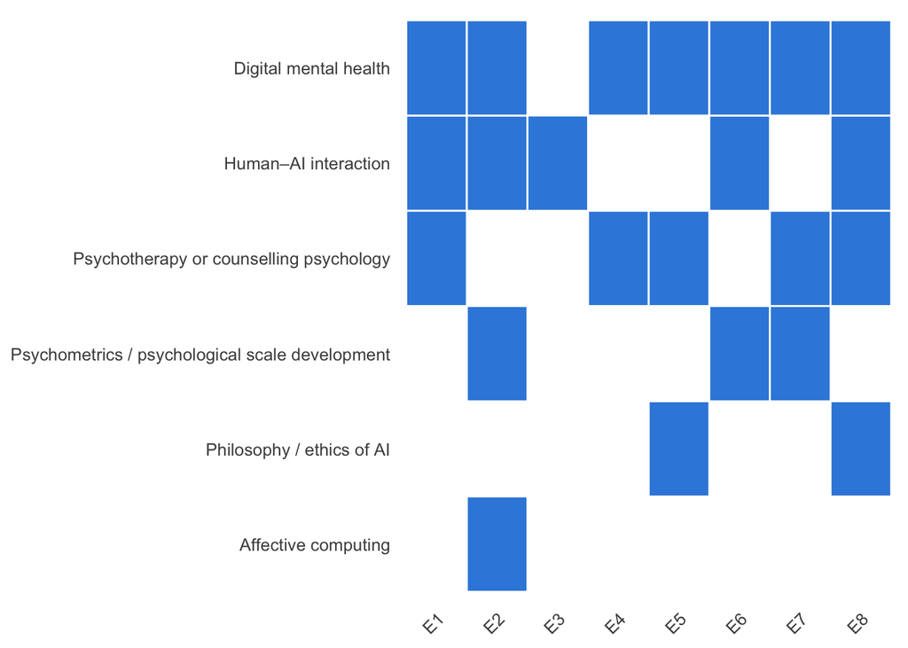

```r
expr_raw <- analysis_data$EXPR

tibble(expert = paste0("E", seq_along(expr_raw)), discipline = expr_raw) %>%
  separate_rows(discipline, sep = ",") %>%
  mutate(discipline = str_trim(discipline)) %>%
  mutate(discipline = fct_infreq(discipline) %>% fct_rev()) %>%  # <- add this
  ggplot(aes(x = expert, y = discipline)) +
  geom_tile(fill = "#378ADD", colour = "white", linewidth = 0.5) +
  labs(x = NULL, y = NULL) +
  theme_minimal(base_size = 12) +
  theme(
    panel.grid  = element_blank(),
    axis.text.x = element_text(angle = 45, hjust = 1)
  )
```

# Agreement

```r
ratings_matrix <- experts_data %>%
  select(all_of(cols_tpsai)) %>%
  mutate(across(everything(), as.integer)) %>%
  as.matrix()

overall_alpha <- kripp.alpha(ratings_matrix, method = "nominal")
overall_alpha
```

```
 Krippendorff's alpha

 Subjects = 40
   Raters = 8
    alpha = 0.0549
```

```r
interpret_alpha <- case_when(
  overall_alpha$value < 0.20 ~ "Slight agreement",
  overall_alpha$value < 0.40 ~ "Fair agreement",
  overall_alpha$value < 0.60 ~ "Moderate agreement",
  overall_alpha$value < 0.80 ~ "Substantial agreement",
  TRUE                        ~ "Almost perfect agreement"
)

cat("Krippendorff's alpha =", round(overall_alpha$value, 3), "-", interpret_alpha)
```

```
Krippendorff's alpha = 0.055 - Slight agreement
```

# Evaluations

Expert judges evaluated each item and voted to Keep, Drop, or Reword it. The majority vote determined the final recommendation for each item. When two options tied, the following rules resolved the decision.

1. Keep and Reword ties favoured Reword on the basis that any doubt about an item warrants revision rather than acceptance.
2. Drop and Reword ties favoured Drop on the basis that if an item is difficult enough to reword that experts are split, it is better removed.
3. Keep and Drop ties favoured Keep, giving the item the benefit of the doubt for further evaluation in subsequent validation stages.

```r
decisions <- experts_data %>%
  pivot_longer(cols = all_of(cols_tpsai), names_to = "item", values_to = "rating") %>%
  mutate(rating = names(choices)[rating]) %>%
  group_by(item) %>%
  summarise(
    n_keep    = sum(rating == "Keep"),
    n_drop    = sum(rating == "Drop"),
    n_reword  = sum(rating == "Reword"),
    pct_agree = round(max(table(rating)) / n(), 2),
    .groups   = "drop"
  ) %>%
  mutate(
    decision = case_when(
      n_reword > n_keep  & n_reword > n_drop  ~ "Reword",
      n_drop   > n_keep  & n_drop   > n_reword ~ "Drop",
      n_keep   > n_drop  & n_keep   > n_reword ~ "Keep",
      n_keep == n_reword & n_keep > n_drop    ~ "Reword",
      n_drop == n_reword & n_drop > n_keep    ~ "Drop",
      n_keep == n_drop  & n_keep > n_reword   ~ "Keep"
    ),
    item = factor(item, levels = cols_tpsai)
  ) %>%
  arrange(item)

kable(decisions, col.names = c("Item", "Keep", "Drop", "Reword", "% Agreement", "Decision"))
```

| Item | Keep | Drop | Reword | % Agreement | Decision |
| --- | --- | --- | --- | --- | --- |
| COMP_01 | 5 | 0 | 3 | 0.62 | Keep |
| COMP_02 | 6 | 0 | 2 | 0.75 | Keep |
| COMP_03 | 3 | 0 | 5 | 0.62 | Reword |
| COMP_04 | 3 | 1 | 4 | 0.50 | Reword |
| COMP_05 | 4 | 3 | 1 | 0.50 | Keep |
| PERS_01 | 3 | 0 | 5 | 0.62 | Reword |
| PERS_02 | 6 | 0 | 2 | 0.75 | Keep |
| PERS_03 | 5 | 0 | 3 | 0.62 | Keep |
| PERS_04 | 6 | 1 | 1 | 0.75 | Keep |
| PERS_05 | 2 | 2 | 4 | 0.50 | Reword |
| EMOT_01 | 5 | 0 | 3 | 0.62 | Keep |
| EMOT_02 | 5 | 0 | 3 | 0.62 | Keep |
| EMOT_03 | 3 | 1 | 4 | 0.50 | Reword |
| EMOT_04 | 6 | 1 | 1 | 0.75 | Keep |
| EMOT_05 | 7 | 0 | 1 | 0.88 | Keep |
| SAFE_01 | 7 | 0 | 1 | 0.88 | Keep |
| SAFE_02 | 6 | 0 | 2 | 0.75 | Keep |
| SAFE_03 | 5 | 0 | 3 | 0.62 | Keep |
| SAFE_04 | 7 | 0 | 1 | 0.88 | Keep |
| SAFE_05 | 6 | 1 | 1 | 0.75 | Keep |
| RISK_01 | 4 | 0 | 4 | 0.50 | Reword |
| RISK_02 | 7 | 0 | 1 | 0.88 | Keep |
| RISK_03 | 5 | 1 | 2 | 0.62 | Keep |
| RISK_04 | 5 | 0 | 3 | 0.62 | Keep |
| RISK_05 | 6 | 0 | 2 | 0.75 | Keep |
| CORP_01 | 8 | 0 | 0 | 1.00 | Keep |
| CORP_02 | 2 | 3 | 3 | 0.38 | Drop |
| CORP_03 | 5 | 0 | 3 | 0.62 | Keep |
| CORP_04 | 7 | 0 | 1 | 0.88 | Keep |
| CORP_05 | 6 | 0 | 2 | 0.75 | Keep |
| CRIT_01 | 4 | 0 | 4 | 0.50 | Reword |
| CRIT_02 | 5 | 2 | 1 | 0.62 | Keep |
| CRIT_03 | 2 | 2 | 4 | 0.50 | Reword |
| CRIT_04 | 7 | 0 | 1 | 0.88 | Keep |
| CRIT_05 | 7 | 0 | 1 | 0.88 | Keep |
| HUMN_01 | 7 | 0 | 1 | 0.88 | Keep |
| HUMN_02 | 8 | 0 | 0 | 1.00 | Keep |
| HUMN_03 | 5 | 0 | 3 | 0.62 | Keep |
| HUMN_04 | 5 | 1 | 2 | 0.62 | Keep |
| HUMN_05 | 8 | 0 | 0 | 1.00 | Keep |

Average agreement (CVI) is 69.95%

**Grouped by dimension**

```r
factor_summary <- decisions %>%
  mutate(factor = str_extract(item, "^[A-Z]+")) %>%
  group_by(factor) %>%
  summarise(
    keep        = sum(n_keep),
    drop        = sum(n_drop),
    reword      = sum(n_reword),
    total       = keep + drop + reword,
    avg_agree   = round(mean(pct_agree) * 100, 1),  # pct_agree is 0-1 in decisions
    .groups     = "drop"
  ) %>%
  mutate(
    pct_keep   = keep   / total * 100,
    pct_reword = reword / total * 100,
    pct_drop   = drop   / total * 100
  ) %>%
  pivot_longer(
    cols = starts_with("pct_"),
    names_to = "decision",
    names_prefix = "pct_",
    values_to = "percentage"
  ) %>%
  mutate(decision = factor(str_to_title(decision), levels = c("Keep", "Reword", "Drop")))

kable(
  factor_summary %>%
    select(factor, decision, percentage, avg_agree) %>%
    pivot_wider(names_from = decision, values_from = percentage) %>%
    select(Factor = factor, Keep, Reword, Drop, `Avg. Agreement (%)` = avg_agree)
)
```

| Factor | Keep | Reword | Drop | Avg. Agreement (%) |
| --- | --- | --- | --- | --- |
| COMP | 52.5 | 37.5 | 10.0 | 59.8 |
| CORP | 70.0 | 22.5 | 7.5 | 72.6 |
| CRIT | 62.5 | 27.5 | 10.0 | 67.6 |
| EMOT | 65.0 | 30.0 | 5.0 | 67.4 |
| HUMN | 82.5 | 15.0 | 2.5 | 82.4 |
| PERS | 55.0 | 37.5 | 7.5 | 64.8 |
| RISK | 67.5 | 30.0 | 2.5 | 67.4 |
| SAFE | 77.5 | 20.0 | 2.5 | 77.6 |

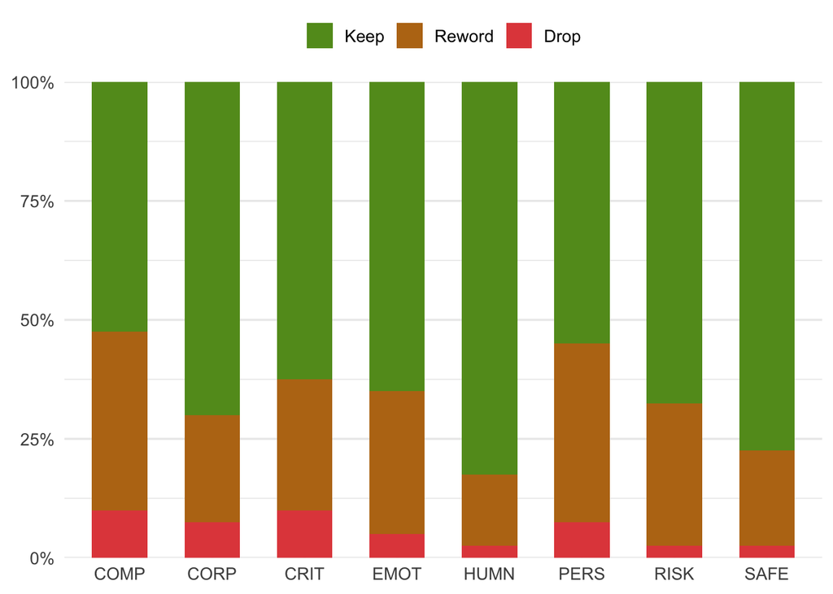

```r
ggplot(factor_summary, aes(x = factor, y = percentage, fill = decision)) +
  geom_col(width = 0.6) +
  scale_fill_manual(values = c(
    "Keep"   = "#639922",
    "Reword" = "#BA7517",
    "Drop"   = "#E24B4A"
  )) +
  labs(x = NULL, y = NULL, fill = NULL, title = NULL) +
  scale_y_continuous(labels = scales::label_percent(scale = 1), expand = c(0, 0)) +
  theme_minimal(base_size = 13) +
  theme(legend.position   = "top")
```

# Additions

```r
analysis_data$COMP_ADD
```

```
[1] "Trust has 2 main components: cognitive and affective. There are many way to operationalize trust. None clear operationalization of the construct emerge here. Please note a systematic review approach https://www.tandfonline.com/doi/full/10.1080/15366367.2025.2485678"
[2] NA
[3] NA
[4] NA
[5] NA
[6] NA
[7] "I trust that it won't lead me to misinformation or harm."
[8] "Something about agency and competence after asking AI, such as: \"I trust that after asking advice from AI, I will be more competent in taking action to solve my psychological difficulties\""
```

```r
analysis_data$PERS_ADD
```

```
[1] "It is not clear the whole section. Why it us labeled “personalization”? How this construct has been identified? What is it about?"
[2] NA
[3] NA
[4] NA
[5] NA
[6] "I trust the AI to adjust its advice to fit my individual needs rather than giving generic responses"
[7] NA
[8] NA
```

```r
analysis_data$EMOT_ADD
```

```
[1] NA
[2] NA
[3] NA
[4] "This may reflect two distinct processes: emotional validation (feeling understood)and emotional regulation (shifting emotional states), which could be worth distinguishing conceptually (and later empirically using EFA, CFA etc)"
[5] "The word trust,I’m thinking of using the word I believe. It sounds clearer from my perspective. When I say I believe this tool can do so and so, compared to when I say I trust, it feels more accurate."
[6] "I trust the AI to provide emotionally supportive responses without being dismissive or superficial."
[7] "Note: I wouldn't label emotions as \"good\" or \"bad\", as different emotions can have different functions and limitations."
[8] NA
```

```r
analysis_data$SAFE_ADD
```

```
[1] NA
[2] NA
[3] NA
[4] "#2 and #4 are a bit similar here, perhaps keep just one of them"
[5] NA
[6] "I trust the AI to respond without making me feel criticised or dismissed."
[7] NA
[8] "\"I trust AI to ultimately suggest to me what is best for me\" or \"I trust that AI has my best interest in mind, when it provides suggestions about what I should do to feel better\""
```

```r
analysis_data$RISK_ADD
```

```
[1] "Please note some Q may be reworded" NA
[3] NA                                   NA
[5] NA                                   NA
[7] NA                                   NA
```

```r
analysis_data$CORP_ADD
```

```
[1] NA               NA               NA               "great section!"
[5] NA               NA               NA               NA
```

```r
analysis_data$CRIT_ADD
```

```
[1] NA NA NA NA NA NA NA NA
```

```r
analysis_data$HUMN_ADD
```

```
[1] NA
[2] NA
[3] NA
[4] NA
[5] NA
[6] NA
[7] "AI cannot comprehend and care about my experiences the same way as another human being."
[8] NA
```